# Personas: One Approved, One Denied

Jake Hoopes

**Purpose.** This notebook explains *why* the model scores an applicant the way it does, using two real, anonymized holdout applicants: one approved and one denied. Each prediction is split into contributions (SHAP values) that show which parts of the application pushed the predicted risk up or down. Any names used for the personas on the presentation slides are made up.

**These two applicants are intentionally selected illustrative examples, not a representative sample.** I filtered the holdout to candidates who fit a clear story (including on their *actual* outcome) and then picked one of each by hand. They show how the model reasons about individual cases; they say nothing about how often the model is right or how typical these drivers are.

**Model.** The scores come from the same refit of the final XGBoost model used in `01_business_impact.Rmd` (holdout AUC 0.7550; the original run scored 0.7556).

**Association, not causation.** A SHAP contribution shows how much a feature moved *this model’s* score, given everything else in the application. It does not show that the characteristic causes default, or that changing it would change the applicant’s real risk.

**Decision rule used for the personas:** the riskiest 10% of applicants by model score are denied; everyone else is approved. Change `deny_share` to try another rule.

```r
deny_share <- 0.10
cutoff <- quantile(holdout_prob, 1 - deny_share)

ho <- holdout_data |>
  mutate(row_id = row_number(),
         prob = holdout_prob,
         risk_percentile = percent_rank(prob),
         risk_rank = min_rank(desc(prob)),   # 1 = riskiest applicant in the holdout
         decision = if_else(prob >= cutoff, "Deny", "Approve"))

tibble(`Deny if predicted risk is at least` = pct(cutoff),
       `Average predicted risk` = pct(mean(ho$prob))) |>
  knitr::kable()
```

| Deny if predicted risk is at least | Average predicted risk |
| --- | --- |
| 17.9% | 8.0% |

## Candidate applicants

The filters below were chosen to produce clear, easy-to-explain examples. Because they use the applicant’s actual outcome, the candidates are a hand-picked subset by design.

**Approved candidate:** no credit bureau record (the borrower a traditional bank turns away), repaid, in the safest half of applicants, has at least two outside scores, aged 22 to 35, currently employed.

**Denied candidate:** in the riskiest 10%, actually had payment difficulties, aged 22 to 45, and does have a credit bureau record (so the denial is not about missing history).

```r
profile_cols <- c("row_id", "prob", "risk_percentile", "TARGET", "age_years",
                  "CODE_GENDER", "years_employed", "NAME_INCOME_TYPE",
                  "OCCUPATION_TYPE", "NAME_EDUCATION_TYPE", "NAME_FAMILY_STATUS",
                  "CNT_CHILDREN", "NAME_HOUSING_TYPE", "AMT_INCOME_TOTAL",
                  "AMT_CREDIT", "AMT_GOODS_PRICE", "AMT_ANNUITY", "ltv",
                  "ext_source_mean", "ext_source_count", "has_bureau_record",
                  "bureau_credits", "fields_missing", "NAME_CONTRACT_TYPE")

approved_candidates <- ho |>
  filter(has_bureau_record == 0, TARGET == 0, risk_percentile <= 0.5,
         ext_source_count >= 2, between(age_years, 22, 35),
         not_currently_employed == 0, OCCUPATION_TYPE != "Missing") |>
  arrange(prob) |>
  slice(seq(1, n(), length.out = min(5, n())) |> round())   # spread across the group

denied_candidates <- ho |>
  filter(decision == "Deny", TARGET == 1, between(age_years, 22, 45),
         has_bureau_record == 1, OCCUPATION_TYPE != "Missing") |>
  arrange(desc(prob)) |>
  slice(seq(1, n(), length.out = min(5, n())) |> round())

approved_candidates |> select(any_of(profile_cols)) |>
  mutate(across(where(is.numeric), ~ round(.x, 3))) |>
  knitr::kable(caption = "Approved candidates")
```

Approved candidates

| row_id | prob | risk_percentile | TARGET | age_years | CODE_GENDER | years_employed | NAME_INCOME_TYPE | OCCUPATION_TYPE | NAME_EDUCATION_TYPE | NAME_FAMILY_STATUS | CNT_CHILDREN | NAME_HOUSING_TYPE | AMT_INCOME_TOTAL | AMT_CREDIT | AMT_GOODS_PRICE | AMT_ANNUITY | ltv | ext_source_mean | ext_source_count | has_bureau_record | bureau_credits | fields_missing | NAME_CONTRACT_TYPE |
| --- | --- | --- | --- | --- | --- | --- | --- | --- | --- | --- | --- | --- | --- | --- | --- | --- | --- | --- | --- | --- | --- | --- | --- |
| 26352 | 0.009 | 0.002 | 0 | 33.629 | F | 10.152 | Commercial associate | Sales staff | Higher education | Single / not married | 0 | House / apartment | 360000 | 630000 | 630000 | 63000.0 | 1.000 | 0.770 | 3 | 0 | 0 | 1 | Revolving loans |
| 10604 | 0.028 | 0.205 | 0 | 29.246 | F | 10.267 | Commercial associate | Laborers | Secondary / secondary special | Married | 1 | House / apartment | 67500 | 152820 | 135000 | 15241.5 | 1.132 | 0.552 | 2 | 0 | 0 | 8 | Cash loans |
| 46906 | 0.036 | 0.315 | 0 | 29.128 | F | 4.266 | State servant | Core staff | Higher education | Married | 0 | House / apartment | 112500 | 540000 | 540000 | 22878.0 | 1.000 | 0.533 | 2 | 0 | 0 | 8 | Cash loans |
| 61302 | 0.045 | 0.421 | 0 | 26.880 | F | 6.716 | Working | High skill tech staff | Higher education | Married | 2 | House / apartment | 450000 | 258768 | 216000 | 23863.5 | 1.198 | 0.502 | 2 | 0 | 0 | 8 | Cash loans |
| 6778 | 0.053 | 0.497 | 0 | 28.000 | F | 0.364 | State servant | Medicine staff | Secondary / secondary special | Married | 1 | House / apartment | 90000 | 180000 | 180000 | 9000.0 | 1.000 | 0.507 | 2 | 0 | 0 | 8 | Revolving loans |

```r
denied_candidates |> select(any_of(profile_cols)) |>
  mutate(across(where(is.numeric), ~ round(.x, 3))) |>
  knitr::kable(caption = "Denied candidates")
```

Denied candidates

| row_id | prob | risk_percentile | TARGET | age_years | CODE_GENDER | years_employed | NAME_INCOME_TYPE | OCCUPATION_TYPE | NAME_EDUCATION_TYPE | NAME_FAMILY_STATUS | CNT_CHILDREN | NAME_HOUSING_TYPE | AMT_INCOME_TOTAL | AMT_CREDIT | AMT_GOODS_PRICE | AMT_ANNUITY | ltv | ext_source_mean | ext_source_count | has_bureau_record | bureau_credits | fields_missing | NAME_CONTRACT_TYPE |
| --- | --- | --- | --- | --- | --- | --- | --- | --- | --- | --- | --- | --- | --- | --- | --- | --- | --- | --- | --- | --- | --- | --- | --- |
| 22892 | 0.607 | 1.000 | 1 | 39.329 | M | 2.261 | Working | Drivers | Secondary / secondary special | Civil marriage | 1 | House / apartment | 202500 | 640080 | 450000 | 31261.5 | 1.422 | 0.096 | 2 | 1 | 3 | 49 | Cash loans |
| 24700 | 0.329 | 0.986 | 1 | 28.468 | F | 1.960 | Working | Core staff | Higher education | Married | 1 | House / apartment | 103500 | 450000 | 450000 | 27324.0 | 1.000 | 0.252 | 2 | 1 | 17 | 49 | Cash loans |
| 38886 | 0.261 | 0.965 | 1 | 41.164 | M | 1.344 | Working | Laborers | Secondary / secondary special | Married | 2 | House / apartment | 157500 | 1303812 | 1138500 | 42187.5 | 1.145 | 0.261 | 3 | 1 | 9 | 48 | Cash loans |
| 36133 | 0.215 | 0.935 | 1 | 39.225 | M | 0.337 | Working | Low-skill Laborers | Secondary / secondary special | Civil marriage | 0 | House / apartment | 90000 | 269550 | 225000 | 14620.5 | 1.198 | 0.367 | 3 | 1 | 1 | 48 | Cash loans |
| 10930 | 0.179 | 0.900 | 1 | 38.716 | M | 1.133 | Working | Drivers | Secondary / secondary special | Married | 0 | House / apartment | 157500 | 835605 | 697500 | 24561.0 | 1.198 | 0.394 | 2 | 1 | 1 | 49 | Cash loans |

```r
approved_pick <- 3
denied_pick   <- 1

personas <- bind_rows(
  approved_candidates |> slice(approved_pick) |> mutate(persona = "Approved"),
  denied_candidates   |> slice(denied_pick)   |> mutate(persona = "Denied")
)
```

## Why the model decided what it did

```r
ex <- explain_applicants(final_internal_xgb, personas)
stopifnot(max(abs(ex$prob - personas$prob)) < 1e-4)  # contributions add up to the score

contrib <- ex$long |>
  mutate(persona = personas$persona[row], theme = theme_of(variable))

by_theme <- contrib |>
  group_by(persona, theme) |>
  summarise(contribution = sum(contribution), .groups = "drop") |>
  filter(abs(contribution) > 0.005) |>
  arrange(persona, desc(abs(contribution)))

by_feature <- contrib |>
  filter(contribution != 0) |>
  group_by(persona) |>
  slice_max(abs(contribution), n = 8) |>
  ungroup() |>
  mutate(direction = if_else(contribution > 0, "raises risk", "lowers risk"))

by_theme |>
  mutate(direction = if_else(contribution > 0, "raises risk", "lowers risk"),
         contribution = round(contribution, 3)) |>
  knitr::kable(caption = "Contribution by theme (log-odds; positive = riskier)")
```

Contribution by theme (log-odds; positive = riskier)

| persona | theme | contribution | direction |
| --- | --- | --- | --- |
| Approved | Outside credit scores | -0.303 | lowers risk |
| Approved | Education | -0.195 | lowers risk |
| Approved | Loan vs. price of goods | -0.100 | lowers risk |
| Approved | Income | -0.079 | lowers risk |
| Approved | Loan size and payments | -0.078 | lowers risk |
| Approved | Gender | -0.077 | lowers risk |
| Approved | Housing and location | -0.051 | lowers risk |
| Approved | Other application details | 0.045 | raises risk |
| Approved | Credit bureau history | 0.026 | raises risk |
| Approved | Age | 0.023 | raises risk |
| Approved | Family | -0.021 | lowers risk |
| Approved | Missing information | -0.015 | lowers risk |
| Approved | Job stability | -0.011 | lowers risk |
| Denied | Outside credit scores | 1.623 | raises risk |
| Denied | Loan vs. price of goods | 0.351 | raises risk |
| Denied | Loan size and payments | 0.277 | raises risk |
| Denied | Gender | 0.131 | raises risk |
| Denied | Job stability | 0.119 | raises risk |
| Denied | Other application details | 0.092 | raises risk |
| Denied | Age | 0.073 | raises risk |
| Denied | Credit bureau history | 0.053 | raises risk |
| Denied | Education | 0.048 | raises risk |
| Denied | Missing information | 0.039 | raises risk |
| Denied | Income | 0.034 | raises risk |
| Denied | Family | 0.029 | raises risk |
| Denied | Housing and location | 0.009 | raises risk |

```r
by_feature |>
  select(persona, column, value, contribution, direction) |>
  mutate(across(c(value, contribution), ~ round(.x, 3))) |>
  knitr::kable(caption = "Top 8 individual drivers per persona")
```

Top 8 individual drivers per persona

| persona | column | value | contribution | direction |
| --- | --- | --- | --- | --- |
| Approved | ext_source_mean | 0.533 | -0.252 | lowers risk |
| Approved | NAME_EDUCATION_TYPEHigher education | 1.000 | -0.160 | lowers risk |
| Approved | credit_to_annuity | 23.603 | -0.089 | lowers risk |
| Approved | ltv | 1.000 | -0.089 | lowers risk |
| Approved | CODE_GENDERM | 0.000 | -0.077 | lowers risk |
| Approved | ext_source_max | 0.579 | 0.067 | raises risk |
| Approved | ext_source_min | 0.487 | -0.051 | lowers risk |
| Approved | NAME_INCOME_TYPEState servant | 1.000 | -0.049 | lowers risk |
| Denied | ext_source_mean | 0.096 | 1.003 | raises risk |
| Denied | ltv | 1.422 | 0.356 | raises risk |
| Denied | ext_source_min | 0.063 | 0.273 | raises risk |
| Denied | EXT_SOURCE_3 | 0.129 | 0.173 | raises risk |
| Denied | AMT_ANNUITY | 31261.500 | 0.139 | raises risk |
| Denied | CODE_GENDERM | 1.000 | 0.131 | raises risk |
| Denied | credit_to_annuity | 20.475 | 0.090 | raises risk |
| Denied | employed_share_of_life | 0.058 | 0.090 | raises risk |

```r
write_csv(by_theme,   file.path(results_dir, "persona_drivers_by_theme.csv"))
write_csv(by_feature, file.path(results_dir, "persona_drivers_by_feature.csv"))
```

The charts below group the contributions into plain-English themes. Red bars pushed the predicted risk up; blue bars pushed it down. Contributions are on the log-odds scale, so they add up to the applicant’s score.

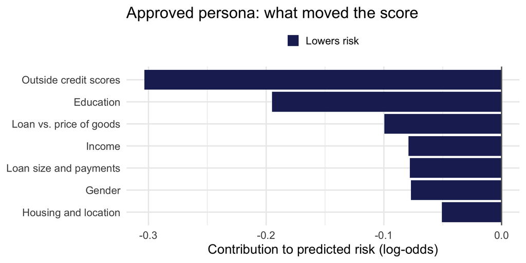

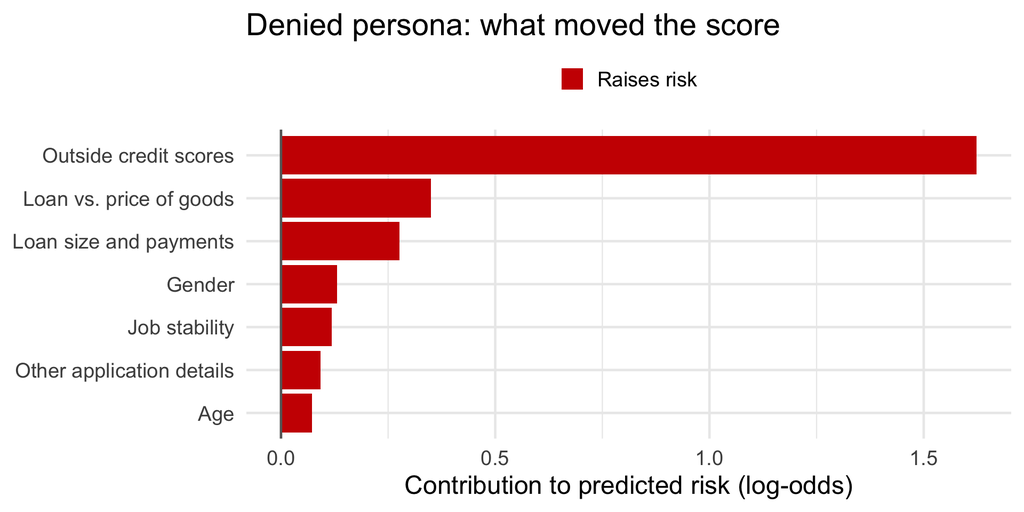

```r
for (p in c("Approved", "Denied")) {
  d <- by_theme |> filter(persona == p) |> slice_max(abs(contribution), n = 7)
  g <- ggplot(d, aes(contribution, fct_reorder(theme, abs(contribution)),
                     fill = contribution > 0)) +
    geom_col() +
    geom_vline(xintercept = 0, colour = "grey40") +
    scale_fill_manual(values = c(`TRUE` = "#CC0000", `FALSE` = "#1E2761"),
                      labels = c(`TRUE` = "Raises risk", `FALSE` = "Lowers risk"), name = NULL) +
    labs(title = paste0(p, " persona: what moved the score"),
         x = "Contribution to predicted risk (log-odds)", y = NULL) +
    theme_minimal(base_size = 18) + theme(legend.position = "top")
  print(g)
  ggsave(file.path(results_dir, paste0("persona_", tolower(p), "_drivers.png")),
         g, width = 11, height = 6, dpi = 200)
}
```

## Age and gender in these explanations

Age and gender are protected characteristics in many lending contexts, and both appear in these explanations.

```r
protected <- contrib |>
  filter(theme %in% c("Gender", "Age")) |>
  group_by(persona, theme) |>
  summarise(contribution = sum(contribution), .groups = "drop") |>
  mutate(direction = if_else(contribution > 0, "raises risk", "lowers risk"))

protected |>
  mutate(contribution = round(contribution, 3)) |>
  knitr::kable(caption = "Gender and age contributions (log-odds; positive = riskier)")
```

Gender and age contributions (log-odds; positive = riskier)

| persona | theme | contribution | direction |
| --- | --- | --- | --- |
| Approved | Age | 0.023 | raises risk |
| Approved | Gender | -0.077 | lowers risk |
| Denied | Age | 0.073 | raises risk |
| Denied | Gender | 0.131 | raises risk |

```r
pc <- function(p, t) protected$contribution[protected$persona == p & protected$theme == t]
```

Gender moved the denied applicant’s score up by 0.13 and the approved applicant’s down by 0.08 (log-odds). Age moved them by 0.07 and 0.02. These are small next to the outside credit scores and are not what drives either decision. But a model that scores applicants partly on gender and age would need a formal fairness and compliance review before any real use, including whether these features should be removed.

## Summary for the slides

```r
avg_risk <- mean(ho$prob)
fmt_profile <- function(r) {
  c(sprintf("- Predicted risk: %s (average applicant %s); risk rank %s of %s (1 = riskiest); decision: %s",
            pct(r$prob), pct(avg_risk), num(r$risk_rank), num(nrow(ho)), r$decision),
    sprintf("- Actual outcome: %s", if_else(r$TARGET == 1, "had payment difficulties", "repaid")),
    sprintf("- Age %d, %s, %s; employed %s years; %s",
            round(r$age_years), r$CODE_GENDER, r$NAME_FAMILY_STATUS,
            round(r$years_employed, 1), r$NAME_INCOME_TYPE),
    sprintf("- Occupation: %s; education: %s; housing: %s; children: %s",
            r$OCCUPATION_TYPE, r$NAME_EDUCATION_TYPE, r$NAME_HOUSING_TYPE, r$CNT_CHILDREN),
    sprintf("- Loan %s (%s) for goods priced %s, loan-to-value %.2f; income %s",
            num(r$AMT_CREDIT), r$NAME_CONTRACT_TYPE, num(r$AMT_GOODS_PRICE), r$ltv,
            num(r$AMT_INCOME_TOTAL)),
    sprintf("- Outside score average %.2f from %d score(s); credit bureau record: %s; blank fields: %d",
            r$ext_source_mean, as.integer(r$ext_source_count),
            if_else(r$has_bureau_record == 1, "yes", "no"), as.integer(r$fields_missing)))
}
lines <- c("# Persona results", "",
           sprintf("Rule: deny the riskiest %s (predicted risk at least %s).",
                   pct(deny_share, 0), pct(cutoff)),
           "",
           "These two applicants were intentionally selected as illustrative examples, not a representative sample.",
           "Contributions are log-odds SHAP values: they show what the model's score is associated with, not what causes default.",
           "")
# One bullet per theme, or a single "none" line when no theme moved risk that way.
driver_lines <- function(d) {
  if (nrow(d) == 0) return("  - None: no theme moved the predicted risk in this direction")
  paste0("  - ", d$theme, " (", round(d$contribution, 2), ")")
}
for (i in seq_len(nrow(personas))) {
  r <- personas[i, ]
  th <- by_theme |> filter(persona == r$persona)
  lower <- th |> filter(contribution < 0) |> head(3)
  raise <- th |> filter(contribution > 0) |> head(3)
  lines <- c(lines, paste0("## ", r$persona, " persona (holdout row ", r$row_id, ")"),
             fmt_profile(r),
             "- Biggest factors lowering risk:",
             driver_lines(lower),
             "- Biggest factors raising risk:",
             driver_lines(raise),
             sprintf("- Protected characteristics: gender %+.2f, age %+.2f (log-odds)",
                     pc(r$persona, "Gender"), pc(r$persona, "Age")),
             "")
}
writeLines(lines, file.path(results_dir, "persona_summary.md"))
cat(lines, sep = "\n")
```

```
## # Persona results
##
## Rule: deny the riskiest 10% (predicted risk at least 17.9%).
##
## These two applicants were intentionally selected as illustrative examples, not a representative sample.
## Contributions are log-odds SHAP values: they show what the model's score is associated with, not what causes default.
##
## ## Approved persona (holdout row 46906)
## - Predicted risk: 3.6% (average applicant 8.0%); risk rank 42,130 of 61,502 (1 = riskiest); decision: Approve
## - Actual outcome: repaid
## - Age 29, F, Married; employed 4.3 years; State servant
## - Occupation: Core staff; education: Higher education; housing: House / apartment; children: 0
## - Loan 540,000 (Cash loans) for goods priced 540,000, loan-to-value 1.00; income 112,500
## - Outside score average 0.53 from 2 score(s); credit bureau record: no; blank fields: 8
## - Biggest factors lowering risk:
##   - Outside credit scores (-0.3)
##   - Education (-0.2)
##   - Loan vs. price of goods (-0.1)
## - Biggest factors raising risk:
##   - Other application details (0.05)
##   - Credit bureau history (0.03)
##   - Age (0.02)
## - Protected characteristics: gender -0.08, age +0.02 (log-odds)
##
## ## Denied persona (holdout row 22892)
## - Predicted risk: 60.7% (average applicant 8.0%); risk rank 1 of 61,502 (1 = riskiest); decision: Deny
## - Actual outcome: had payment difficulties
## - Age 39, M, Civil marriage; employed 2.3 years; Working
## - Occupation: Drivers; education: Secondary / secondary special; housing: House / apartment; children: 1
## - Loan 640,080 (Cash loans) for goods priced 450,000, loan-to-value 1.42; income 202,500
## - Outside score average 0.10 from 2 score(s); credit bureau record: yes; blank fields: 49
## - Biggest factors lowering risk:
##   - None: no theme moved the predicted risk in this direction
## - Biggest factors raising risk:
##   - Outside credit scores (1.62)
##   - Loan vs. price of goods (0.35)
##   - Loan size and payments (0.28)
## - Protected characteristics: gender +0.13, age +0.07 (log-odds)
```